# Exam 2

**You’re going to be looking at UNICEF data regarding child mortality rates for children under 5 years old. The file “unicef-u5mr.csv” contains this data set.**

**“U5MR” refers to ‘under-5 years old mortality rate,’ and there is a time component to the data, which is also broken down by country, region, and continent.**

**The mortality rate values are expressed as number of deaths (before age 5) per 1000 live births.**

**It’s a sombering set of data at first glance, but actually tells a mostly encouraging story. It’s up to you to uncover that story. To do so, you will have to clean, plot, and model the data.**

**Here’s a glimpse of the data structure:**

Data summary

[output not shown]

**Variable type: character**

| skim_variable | n_missing | complete_rate | min | max | empty | n_unique | whitespace |
| --- | --- | --- | --- | --- | --- | --- | --- |
| CountryName | 0 | 1 | 4 | 30 | 0 | 196 | 0 |
| Continent | 0 | 1 | 4 | 8 | 0 | 5 | 0 |
| Region | 0 | 1 | 9 | 25 | 0 | 22 | 0 |

**Variable type: numeric**

| skim_variable | n_missing | complete_rate | mean | sd | p0 | p25 | p50 | p75 | p100 | hist |
| --- | --- | --- | --- | --- | --- | --- | --- | --- | --- | --- |
| U5MR.1950 | 167 | 0.15 | 151.74 | 124.92 | 27.1 | 37.70 | 115.50 | 256.70 | 389.7 | ▇▃▁▂▃ |
| U5MR.1951 | 157 | 0.20 | 158.14 | 122.52 | 25.7 | 39.60 | 121.30 | 261.05 | 388.8 | ▇▃▂▂▃ |
| U5MR.1952 | 152 | 0.22 | 160.86 | 116.75 | 24.4 | 43.05 | 127.80 | 264.18 | 384.1 | ▇▃▂▃▃ |
| U5MR.1953 | 142 | 0.28 | 164.36 | 110.40 | 23.2 | 48.12 | 147.95 | 265.05 | 380.4 | ▇▃▃▅▂ |
| U5MR.1954 | 132 | 0.33 | 154.80 | 103.75 | 22.3 | 56.58 | 132.95 | 251.43 | 376.5 | ▇▃▃▃▂ |
| U5MR.1955 | 124 | 0.37 | 158.19 | 102.64 | 21.6 | 59.35 | 153.90 | 241.42 | 372.3 | ▇▃▅▅▂ |
| U5MR.1956 | 113 | 0.42 | 162.99 | 103.27 | 21.1 | 64.40 | 158.40 | 247.40 | 388.9 | ▇▅▅▅▂ |

## Tasks:

**1. Read in the unicef data (10 pts)** **2. Get it into tidy format (10 pts)** **3. Plot each country’s U5MR over time (20 points)**

```
- Create a line plot (not a smooth trend line) for each country
- Facet by continent
- Something like this:
```

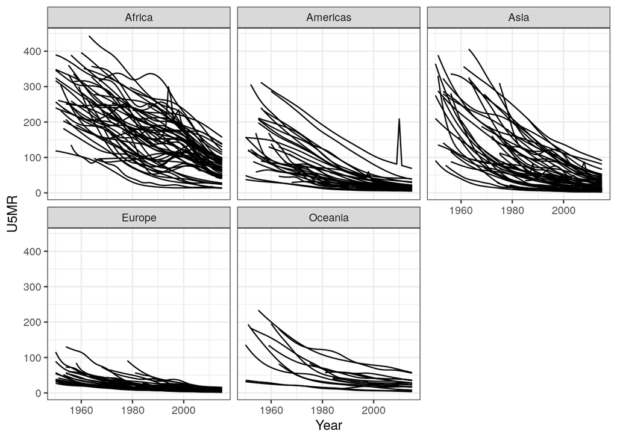

**4. Save this plot as LASTNAME_Plot_1.png (5 pts)** **5. Create another plot that shows the mean U5MR for all the countries within a given continent at each year (20 pts)**

```
- Another line plot (not smooth trendline)
- Colored by continent
- Something like this:
```

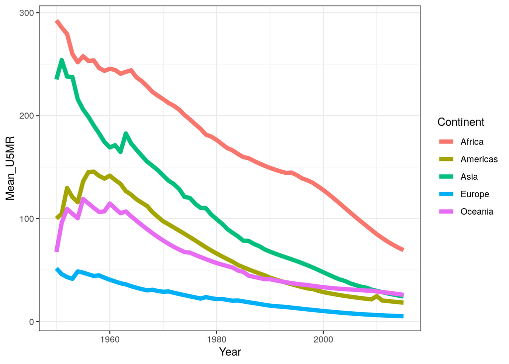

**6. Save that plot as LASTNAME_Plot_2.png (5 pts)** **7. Create three models of U5MR (20 pts)**

```
- mod1 should account for only Year
- mod2 should account for Year and Continent
- mod3 should account for Year, Continent, and their interaction term
```

**8. Compare the three models with respect to their performance**

```
- Your code should do the comparing
- Include a comment line explaining which of these three models you think is best
```

**9. Plot the 3 models’ predictions like so: (10 pts)**

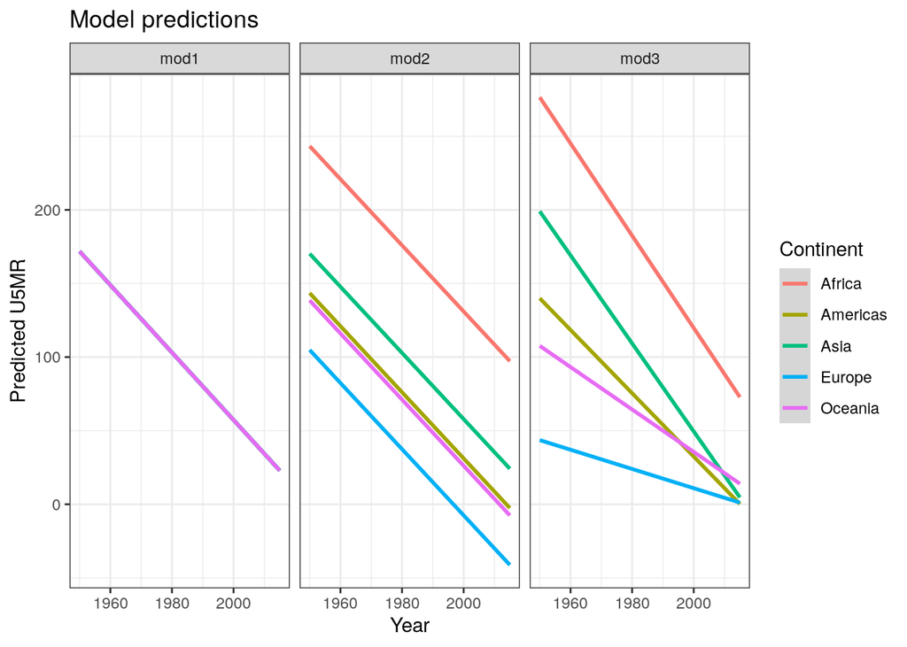

[output not shown]

**10. BONUS - Using your preferred model, predict what the U5MR would be for Ecuador in the year 2020. The real value for Ecuador for 2020 was 13 under-5 deaths per 1000 live births. How far off was your model prediction???**

Your code should predict the value using the model and calculate the difference between the model prediction and the real value (13).

Source: https://data.unicef.org/country/ecu/

Create any model of your choosing that improves upon this “Ecuadorian measure of model correctness.” By transforming the data, I was able to find a model that predicted Ecuador would have a U5MR of 16.61…not too far off from reality

```
##   Model Prediction Reality
## 1  mod4   16.61356      13
```